# Homework 04: Visualization, Correlation, and Linear Models

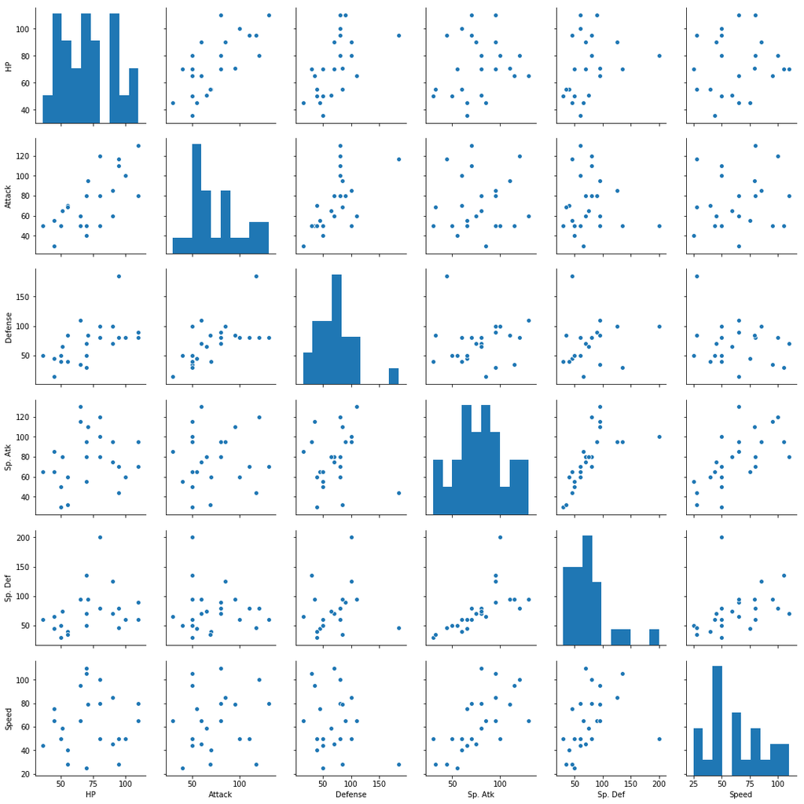

```python
sns.pairplot(pok_ability[pok_ability['Type 1'] == 'Ice'])
```

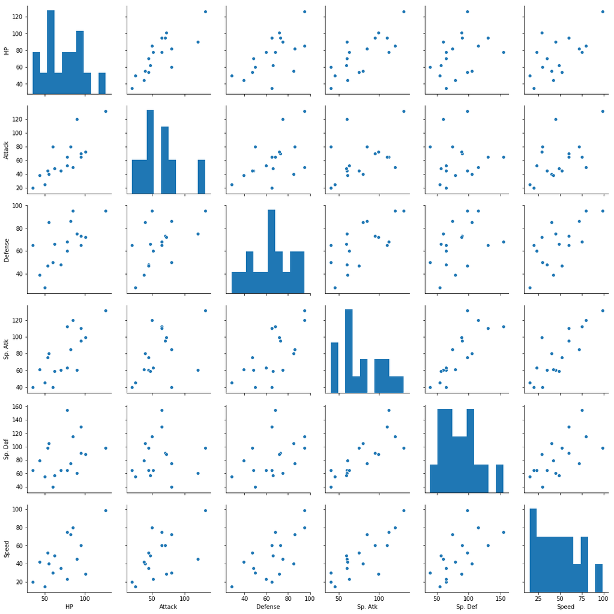

```python
sns.pairplot(pok_ability[pok_ability['Type 1'] == 'Fairy'])
```

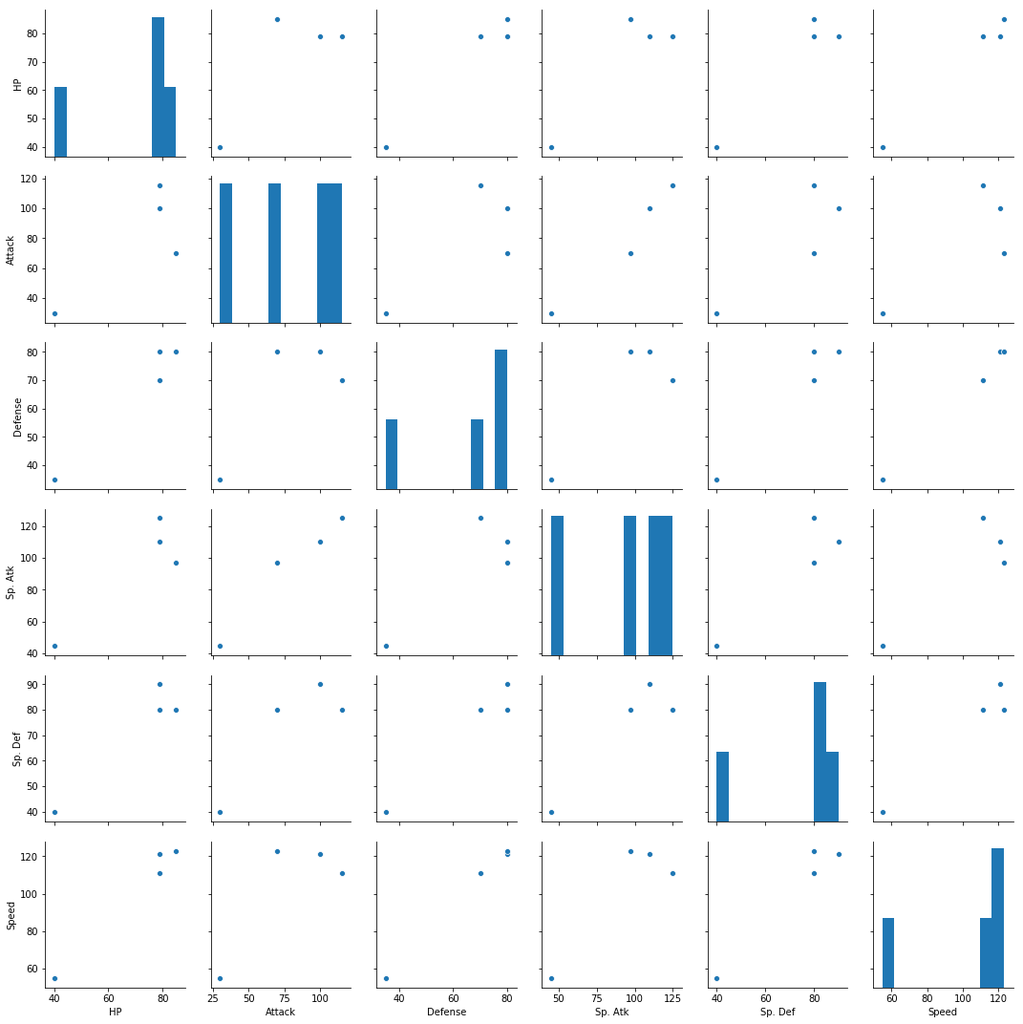

```python
sns.pairplot(pok_ability[pok_ability['Type 1'] == 'Flying'])
```

- For Flying pokemons, given limited samples (only 4), most abilities are distributed radically meaning that for 5 of 6 ability genres, their points are either high or low. Which means the strength and weakness of most flying pokemons are very evident.
- For Water pokemons, the distributions of their sex ability points are approximately normal with slight right skewness. Which means for most of them, the abilities are not extraordinary or poor but mediocre.
- For Ground pokemons, HP and Speed ability points are relatively universe with peaks near higher independent value, indicating that the proportion of samples having excellent performace on HP and Speed are relatively higher than some other types.

### Q6. For 15 Points: Explore how the Pokémon in each generation differ from each other?

- Do you think designers of *Pokémon* tried to address different distributions of ability points in each generation?

```python
pok_ability_gen = pok[['Type 1','HP','Attack','Defense','Sp. Atk',\
    'Sp. Def','Speed', 'Generation']].copy()
pok_ability_gen.head()
```

|  | Type 1 | HP | Attack | Defense | Sp. Atk | Sp. Def | Speed | Generation |
| --- | --- | --- | --- | --- | --- | --- | --- | --- |
| 0 | Grass | 45 | 49 | 49 | 65 | 65 | 45 | 1 |
| 1 | Grass | 60 | 62 | 63 | 80 | 80 | 60 | 1 |
| 2 | Grass | 80 | 82 | 83 | 100 | 100 | 80 | 1 |
| 3 | Grass | 80 | 100 | 123 | 122 | 120 | 80 | 1 |
| 4 | Fire | 39 | 52 | 43 | 60 | 50 | 65 | 1 |

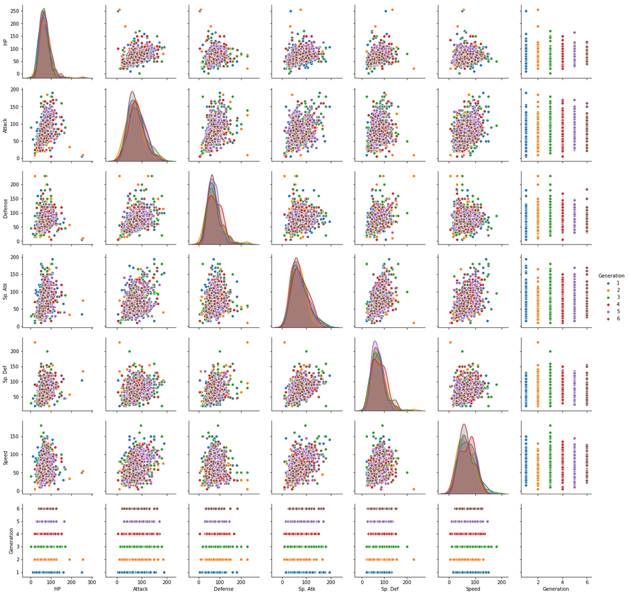

```python
sns.pairplot(pok_ability_gen, hue = 'Generation')
```

The distributions of different ability points among generations are represented by pairplot above (differentiated by colors). It seems like the fourth generation as a whole has slightly better performance on Speed and Defense than the rest generations. However, overall, I think the difference of distributions among generations are pretty small because their distributions are pretty much overlapped. So that I don't think the designers of Pokemon tried to address different distributions of ability points in each generation.